# Prédire l’âge au premier alcool

Author

Kacer Mathis, Leal-Fernandes Marylou

# Introduction

Après l’analyse descriptive du jeu de données ESCAPAD 2017, nous cherchons maintenant à prédire l’âge au premier alcool à partir des caractéristiques des jeunes et de leur contexte familial. Nous avons choisi de traiter ce problème comme une **classification** : l’âge au premier alcool est découpé en classes (≤ 13 ans, 14-15 ans, ≥ 16 ans), auxquelles on ajoute une classe « Non concerné » pour les jeunes n’ayant jamais bu. Cela permet de modéliser tous les jeunes, y compris ceux qui n’ont jamais bu, et d’éviter que les âges extrêmes (1 à 5 ans) pèsent plus que les autres.

Nous présentons d’abord la variable discrétisée, puis les modèles un par un, des plus simples (modèles de référence) aux méthodes d’agrégation (bagging, forêt aléatoire, boosting, stacking), avant de les comparer et d’analyser le meilleur d’entre eux.

# Préparation

## Chargement des outils

```python
import sys
import time
from pathlib import Path

import matplotlib.pyplot as plt
import numpy as np
import pandas as pd
from joblib import Parallel, delayed
from matplotlib.colors import LinearSegmentedColormap
from sklearn.base import clone
from sklearn.dummy import DummyClassifier
from sklearn.ensemble import (
    BaggingClassifier,
    GradientBoostingClassifier,
    HistGradientBoostingClassifier,
    RandomForestClassifier,
    StackingClassifier,
)
from sklearn.inspection import permutation_importance
from sklearn.linear_model import LogisticRegression
from sklearn.metrics import (
    accuracy_score,
    confusion_matrix,
    f1_score,
    log_loss,
    roc_auc_score,
)
from sklearn.model_selection import ParameterGrid, StratifiedKFold, train_test_split
from sklearn.pipeline import Pipeline
from sklearn.preprocessing import LabelEncoder
from sklearn.tree import DecisionTreeClassifier
from xgboost import XGBClassifier

# Permet d'importer le package data depuis le dossier du projet
ROOT = Path.cwd() if (Path.cwd() / "data").is_dir() else Path.cwd().parent

if str(ROOT) not in sys.path:
    sys.path.insert(0, str(ROOT))

from data import load_escap_data, preprocess
from data.features import FEATURES, make_preprocessor
from data.labels import NON_CONCERNE, TARGET, VARIABLES, WEIGHT
from data.preprocess import TARGET_CLASS

pd.set_option("display.width", 200)
pd.set_option("display.max_columns", 50)

SEED = 42
N_JOBS = -1

# Palette : une couleur principale, une secondaire, des gris pour le reste.
BLUE = "#2a78d6"
ORANGE = "#eb6834"
GREY = "#8a8985"
TEXT = "#52514e"

# Rampe séquentielle bleue (blanc -> foncé) pour les matrices de confusion.
BLUE_RAMP = ["#ffffff", "#cde2fb", "#86b6ef", "#3987e5", "#1c5cab", "#0d366b"]

plt.rcParams.update(
    {
        "figure.dpi": 110,
        "axes.spines.top": False,
        "axes.spines.right": False,
        "axes.edgecolor": GREY,
        "axes.labelcolor": TEXT,
        "axes.titleweight": "bold",
        "axes.titlesize": 11,
        "axes.labelsize": 9,
        "xtick.color": TEXT,
        "ytick.color": TEXT,
        "xtick.labelsize": 8,
        "ytick.labelsize": 8,
        "axes.grid": True,
        "grid.color": "#e4e3df",
        "grid.linewidth": 0.6,
        "axes.axisbelow": True,
        "legend.frameon": False,
        "legend.fontsize": 8,
    }
)
```

## Variables explicatives

Les variables explicatives sont encodées de la façon suivante (voir `data/features.py`) :

- les **variables ordinales** (sexe, redoublement, difficultés de lecture et d’écriture, consommation d’alcool du père et de la mère) sont codées par un score qui conserve l’ordre des modalités. Les non-réponses sont remplacées par la médiane et signalées par une indicatrice, car elles ne sont pas aléatoires ;
- les **variables nominales** (`SITUATION`, lieu de vie, vie des parents, situation et PCS des parents) sont codées en indicatrices. Les modalités de moins de 30 individus sont regroupées.

Certaines variables sont exclues : l’identifiant `A01`, le poids de sondage `pm17B` (utilisé comme pondération et non comme prédicteur), `Q04`, `Q04A` et `Q04B` (résumées par `SITUATION`) et bien sûr la cible elle-même.

## Protocole

Nous avons suivi le même protocole pour tous les modèles :

- un découpage 80 % apprentissage / 20 % test, stratifié sur la classe d’âge (même répartition des classes dans les deux échantillons) ;
- le choix des hyperparamètres par validation croisée à 5 plis sur l’échantillon d’apprentissage ;
- l’apprentissage et toutes les métriques sont pondérés par `pm17B` ;
- l’échantillon test n’est utilisé qu’une fois, pour évaluer le modèle retenu.

La fonction ci-dessous teste toutes les combinaisons d’hyperparamètres d’une grille en validation croisée et renvoie la meilleure.

```python
def make_pipe(estimator) -> Pipeline:
    """Encodage des variables suivi du modèle."""
    return Pipeline([("prep", make_preprocessor()), ("model", estimator)])


def _fit_score(estimator, params, X, y, w, train_idx, val_idx, score):
    pipe = make_pipe(clone(estimator).set_params(**params))
    pipe.fit(X.iloc[train_idx], y.iloc[train_idx],
             model__sample_weight=w.iloc[train_idx].to_numpy())
    return score(pipe, X.iloc[val_idx], y.iloc[val_idx], w.iloc[val_idx])


def grid_search(estimator, grid, X, y, w, cv, score):
    """Meilleure combinaison d'hyperparamètres (score à minimiser) en validation croisée."""
    combos = list(ParameterGrid(grid or {}))
    scores = Parallel(n_jobs=N_JOBS)(
        delayed(_fit_score)(estimator, p, X, y, w, tr, va, score) for p in combos for tr, va in cv
    )
    scores = np.asarray(scores).reshape(len(combos), len(cv))
    best = scores.mean(1).argmin()
    return combos[best], scores[best].mean(), scores[best].std()


def result_table(res: dict, name: str) -> pd.DataFrame:
    """Résultats d'un modèle, hyperparamètres compris."""
    out = pd.Series({k: round(v, 4) for k, v in res.items() if k != "hyperparamètres"},
                    dtype=object)
    out["hyperparamètres"] = ", ".join(
        f"{k} = {v:.3g}" if isinstance(v, float) else f"{k} = {v}"
        for k, v in res["hyperparamètres"].items()
    ) or "—"
    return out.to_frame(name)
```

# La variable à prédire

## Construction des classes

Nous découpons l’âge au premier alcool `Q19A` en trois classes et nous gardons **tous les jeunes**, y compris ceux qui n’ont jamais bu :

| Classe | Contenu |
| --- | --- |
| ≤ 13 ans | initiation précoce |
| 14-15 ans | âge le plus courant |
| ≥ 16 ans | initiation tardive |
| Non concerné | n’a jamais bu (`Q19A` manquant) |

Nous avions d’abord découpé l’âge par quartiles, ce qui donnait quatre classes d’âge (≤ 13 / 14 / 15 / ≥ 16 ans). Mais les modèles ne distinguaient pas les jeunes de 14 et de 15 ans : ils leur attribuaient les mêmes probabilités, et la classe « 14 ans » n’était jamais prédite. Nous avons donc regroupé 14 et 15 ans, en fixant les seuils à la main (13 et 15 ans). Comme pour le prétraitement, les âges supérieurs à 25 ans, incohérents, sont supprimés.

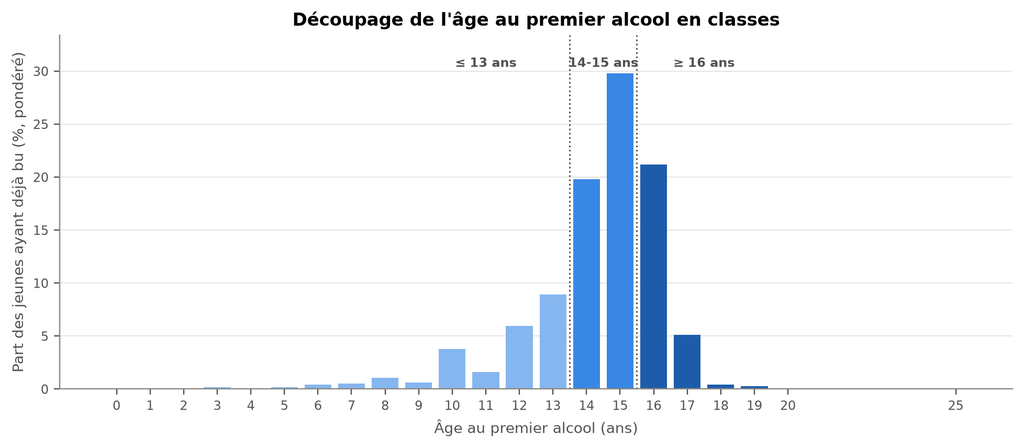

```python
df_clf = preprocess(load_escap_data(), thresholds=[13, 15])
CLASSES = list(df_clf[TARGET_CLASS].cat.categories)
CLASS_COLORS = ["#86b6ef", "#3987e5", "#1c5cab", GREY]  # précoce -> tardif, puis non concerné

drinkers = df_clf[TARGET].notna()
ages, w_ages = df_clf.loc[drinkers, TARGET], df_clf.loc[drinkers, WEIGHT]
dist = w_ages.groupby(ages).sum() / w_ages.sum() * 100
class_idx = np.searchsorted([13, 15], dist.index, side="left")

fig, ax = plt.subplots(figsize=(9, 4))
ax.bar(dist.index, dist.values, color=[CLASS_COLORS[i] for i in class_idx], width=0.8)
for t in (13, 15):
    ax.axvline(t + 0.5, color=TEXT, linestyle=":", linewidth=1)
for i in range(3):
    ax.annotate(CLASSES[i], ((11, 14.5, 17.5)[i], dist.max() * 1.02),
                ha="center", fontsize=8, color=TEXT, fontweight="bold")
ax.set_xticks(dist.index.astype(int))
ax.set_xlabel("Âge au premier alcool (ans)")
ax.set_ylabel("Part des jeunes ayant déjà bu (%, pondéré)")
ax.set_title("Découpage de l'âge au premier alcool en classes")
ax.set_ylim(0, dist.max() * 1.12)
ax.grid(axis="x", visible=False)
plt.tight_layout()
plt.show()
```

## Répartition des classes

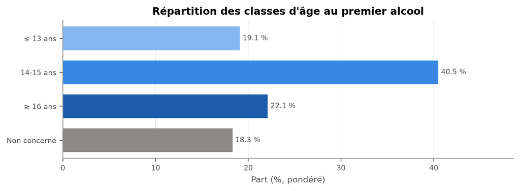

```
Individus : 13311
```

| Q19A_CLASSE | effectif | % pondéré | âge moyen 1er alcool |
| --- | --- | --- | --- |
| ≤ 13 ans | 2551 | 19.1 | 11.32 |
| 14-15 ans | 5394 | 40.5 | 14.60 |
| ≥ 16 ans | 2973 | 22.1 | 16.26 |
| Non concerné | 2393 | 18.3 | NaN |

```python
yc, wc = df_clf[TARGET_CLASS].astype(str), df_clf[WEIGHT]
stats_class = pd.DataFrame(
    {
        "effectif": yc.value_counts().reindex(CLASSES),
        "% pondéré": (wc.groupby(yc).sum().reindex(CLASSES) / wc.sum() * 100).round(1),
        "âge moyen 1er alcool": (
            df_clf[drinkers]
            .groupby(TARGET_CLASS, observed=False)[[TARGET, WEIGHT]]
            .apply(lambda g: np.average(g[TARGET], weights=g[WEIGHT]) if len(g) else np.nan)
            .round(2)
        ),
    }
)

fig, ax = plt.subplots(figsize=(8, 3))
bars = ax.barh(CLASSES, stats_class["% pondéré"], color=CLASS_COLORS, height=0.7)
ax.bar_label(bars, fmt="%.1f %%", padding=3, fontsize=8, color=TEXT)
ax.invert_yaxis()
ax.set_xlim(0, stats_class["% pondéré"].max() * 1.2)
ax.set_xlabel("Part (%, pondéré)")
ax.set_title("Répartition des classes d'âge au premier alcool")
ax.grid(axis="y", visible=False)
plt.tight_layout()
plt.show()

print(f"Individus : {len(df_clf)}")
stats_class
```

La classe centrale « 14-15 ans » regroupe 40,5 % des jeunes (pondéré). Les trois autres classes ont des tailles proches : 19,1 % de précoces, 22,1 % de tardifs et 18,3 % de jeunes n’ayant jamais bu. L’âge moyen au premier alcool est de 11,3 ans chez les précoces, 14,6 ans dans la classe centrale et 16,3 ans chez les tardifs. Un modèle qui prédirait toujours la classe « 14-15 ans » aurait donc déjà une exactitude d’environ 40 %.

## Les classes selon quelques variables

Avant de modéliser, nous avons regardé comment la répartition des classes varie selon le sexe et la consommation d’alcool des parents, les variables qui ressortaient de l’analyse descriptive. Les modalités de moins de 30 jeunes sont écartées.

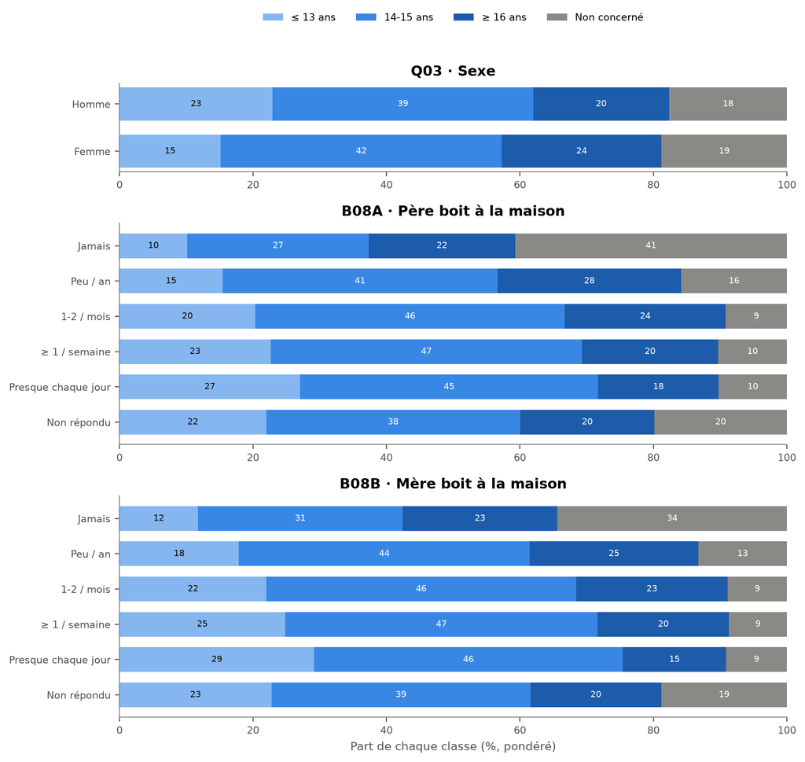

```python
fig, axes = plt.subplots(3, 1, figsize=(9, 8.5), gridspec_kw={"height_ratios": [2, 5, 5]})
for ax, var in zip(axes, ("Q03", "B08A", "B08B")):
    data = pd.DataFrame({"mod": df_clf[var], "classe": df_clf[TARGET_CLASS], "w": wc})
    counts = data["mod"].value_counts()
    data = data[data["mod"].isin(counts[counts >= 30].index)]
    tab = data.pivot_table(index="mod", columns="classe", values="w", aggfunc="sum",
                           observed=True).reindex(columns=CLASSES)
    tab = tab.div(tab.sum(axis=1), axis=0) * 100
    left = np.zeros(len(tab))
    for c, color in zip(CLASSES, CLASS_COLORS):
        ax.barh(tab.index.astype(str), tab[c], left=left, color=color, height=0.7, label=c)
        for y_, (l_, v) in enumerate(zip(left, tab[c])):
            if v >= 6:
                ax.text(l_ + v / 2, y_, f"{v:.0f}", ha="center", va="center", fontsize=7,
                        color="white" if c != "≤ 13 ans" else "#0b0b0b")
        left += tab[c].to_numpy()
    ax.invert_yaxis()
    ax.set_xlim(0, 100)
    ax.set_title(f"{var} · {VARIABLES[var][0]}")
    ax.grid(False)
axes[-1].set_xlabel("Part de chaque classe (%, pondéré)")
axes[0].legend(ncols=4, loc="upper center", bbox_to_anchor=(0.5, 1.9))
plt.tight_layout()
plt.show()
```

Les garçons sont plus souvent précoces que les filles (23 % contre 15 %), alors que les filles sont un peu plus souvent dans les classes « 14-15 ans » et « ≥ 16 ans ». La part de jeunes n’ayant jamais bu est proche pour les deux sexes (18 et 19 %).

La consommation d’alcool des parents joue sur deux plans :

- **sur le fait d’avoir bu ou non** : quand le père ne boit jamais à la maison, 41 % des jeunes n’ont jamais bu, contre 9 à 16 % quand il boit ; pour la mère, c’est 34 % contre 9 à 13 % ;
- **sur la précocité** : plus les parents boivent souvent, plus les jeunes sont précoces. La part de « ≤ 13 ans » passe de 10 % quand le père ne boit jamais à 27 % quand il boit presque chaque jour (de 12 % à 29 % pour la mère), et la part de tardifs diminue.

Ces variables devraient donc surtout aider à repérer les jeunes n’ayant jamais bu, et dans une moindre mesure les précoces.

# Les modèles

## Mise en place

Les hyperparamètres sont choisis en minimisant la **log-loss** pondérée, qui évalue les probabilités prédites. Elle est plus stable que l’exactitude quand le signal est faible, car l’exactitude ne dépend que de la classe prédite. Nous reportons aussi l’exactitude, le F1 macro (moyenne des F1 de chaque classe) et l’AUC macro One-vs-Rest (capacité des probabilités à classer les individus, 0,5 correspondant au hasard).

```python
Xc = df_clf[FEATURES]
Xc_train, Xc_test, yc_train, yc_test, wc_train, wc_test = train_test_split(
    Xc, yc, wc, test_size=0.2, stratify=yc, random_state=SEED
)
CV_CLF = list(StratifiedKFold(5, shuffle=True, random_state=SEED).split(Xc_train, yc_train))


def logloss_score(pipe, X, y, w):
    return log_loss(y, pipe.predict_proba(X), sample_weight=w, labels=pipe.classes_)


RES_CLF, FIT_CLF = {}, {}


def evaluate_clf(name, estimator, grid=None):
    """Choisit les hyperparamètres en CV, réapprend sur tout l'apprentissage, évalue sur le test."""
    start = time.time()
    params, cv_mean, cv_std = grid_search(
        estimator, grid, Xc_train, yc_train, wc_train, CV_CLF, logloss_score
    )
    pipe = make_pipe(clone(estimator).set_params(**params))
    pipe.fit(Xc_train, yc_train, model__sample_weight=wc_train.to_numpy())
    pred, proba = pipe.predict(Xc_test), pipe.predict_proba(Xc_test)
    FIT_CLF[name] = pipe
    RES_CLF[name] = {
        "log-loss CV": cv_mean,
        "± CV": cv_std,
        "log-loss test": logloss_score(pipe, Xc_test, yc_test, wc_test),
        "exactitude test": accuracy_score(yc_test, pred, sample_weight=wc_test),
        "F1 macro test": f1_score(yc_test, pred, average="macro", sample_weight=wc_test),
        "AUC macro test": roc_auc_score(yc_test, proba, multi_class="ovr", average="macro",
                                        sample_weight=wc_test, labels=pipe.classes_),
        "temps (s)": time.time() - start,
        "hyperparamètres": params,
    }
    return result_table(RES_CLF[name], name)


print(f"Apprentissage : {len(Xc_train)} — test : {len(Xc_test)}")
```

```
Apprentissage : 10648 — test : 2663
```

## Les modèles de référence

### La classe majoritaire

Ce modèle n’utilise aucune variable : il attribue à chaque jeune les fréquences des classes comme probabilités et prédit toujours la classe la plus fréquente, « 14-15 ans ».

```python
evaluate_clf("Classe majoritaire", DummyClassifier(strategy="prior"))
```

|  | Classe majoritaire |
| --- | --- |
| log-loss CV | 1.3267 |
| ± CV | 0.0016 |
| log-loss test | 1.3255 |
| exactitude test | 0.4072 |
| F1 macro test | 0.1447 |
| AUC macro test | 0.5 |
| temps (s) | 2.1056 |
| hyperparamètres | — |

On obtient une log-loss de 1,326, une exactitude de 40,7 % (la part des 14-15 ans) et une AUC de 0,5 : c’est ce que l’on peut prédire sans rien savoir des jeunes.

### Les régressions logistiques pénalisées

Nous avons testé trois pénalités pour la régression logistique multinomiale, `C` étant l’inverse de la force de la pénalité :

- **ridge** (L2) : réduit tous les coefficients sans en annuler ;
- **lasso** (L1) : annule une partie des coefficients, ce qui revient à sélectionner des variables ;
- **elastic net** : mélange des deux, `l1_ratio` étant la part de L1.

```python
evaluate_clf(
    "Logistique ridge",
    LogisticRegression(max_iter=5000),
    {"C": [float(c) for c in np.logspace(-3, 1, 9)]},
)
```

|  | Logistique ridge |
| --- | --- |
| log-loss CV | 1.2496 |
| ± CV | 0.0044 |
| log-loss test | 1.2478 |
| exactitude test | 0.4432 |
| F1 macro test | 0.2788 |
| AUC macro test | 0.645 |
| temps (s) | 4.3083 |
| hyperparamètres | C = 0.0316 |

```python
evaluate_clf(
    "Logistique lasso",
    LogisticRegression(l1_ratio=1.0, solver="saga", max_iter=5000),
    {"C": [float(c) for c in np.logspace(-3, 1, 9)]},
)
```

|  | Logistique lasso |
| --- | --- |
| log-loss CV | 1.2504 |
| ± CV | 0.0039 |
| log-loss test | 1.247 |
| exactitude test | 0.4446 |
| F1 macro test | 0.2715 |
| AUC macro test | 0.6462 |
| temps (s) | 22.1659 |
| hyperparamètres | C = 0.1 |

```python
evaluate_clf(
    "Logistique elastic net",
    LogisticRegression(solver="saga", max_iter=5000),
    {"C": [float(c) for c in np.logspace(-3, 1, 9)], "l1_ratio": [0.25, 0.5, 0.75]},
)
```

|  | Logistique elastic net |
| --- | --- |
| log-loss CV | 1.2498 |
| ± CV | 0.0043 |
| log-loss test | 1.2475 |
| exactitude test | 0.4443 |
| F1 macro test | 0.2763 |
| AUC macro test | 0.6455 |
| temps (s) | 39.7281 |
| hyperparamètres | C = 0.1, l1_ratio = 0.5 |

Les trois pénalités donnent des résultats identiques : une log-loss d’environ 1,248, une exactitude d’environ 44,4 % et une AUC de 0,645. Le gain par rapport à la classe majoritaire est d’environ 6 % sur la log-loss.

Le lasso est tout de même intéressant pour l’interprétation, car il annule une partie des coefficients. Le tableau suivant donne le nombre de coefficients non nuls de chaque modèle, puis les modalités écartées.

```python
LOGITS = ("Logistique ridge", "Logistique lasso", "Logistique elastic net")
coef_names = FIT_CLF["Logistique ridge"].named_steps["prep"].get_feature_names_out()
nonzero = pd.DataFrame(
    {n: np.abs(FIT_CLF[n].named_steps["model"].coef_).max(0) > 1e-10 for n in LOGITS},
    index=coef_names,
)
print(nonzero.sum().to_string(), f"\nsur {len(coef_names)} coefficients par classe")
nonzero[~nonzero.all(axis=1)]
```

```
Logistique ridge          67
Logistique lasso          41
Logistique elastic net    55
sur 67 coefficients par classe
```

|  | Logistique ridge | Logistique lasso | Logistique elastic net |
| --- | --- | --- | --- |
| missingindicator_Q03 | True | False | False |
| missingindicator_Q05 | True | False | False |
| missingindicator_Q06A | True | False | False |
| missingindicator_Q06B | True | False | False |
| SITUATION_Arrêt : Recherche emploi | True | False | True |
| SITUATION_Arrêt : Sans activité | True | False | False |
| SITUATION_Arrêt : Travaille | True | False | True |
| SITUATION_infrequent_sklearn | True | False | True |
| Q08_Autre | True | False | True |
| Q08_Foyer / fam. accueil | True | False | False |
| Q08_Non répondu | True | False | False |
| Q08C_Autre | True | False | False |
| Q08C_Décès | True | False | False |
| Q08C_Non répondu | True | False | False |
| Q08C_infrequent_sklearn | True | False | False |
| Q09A1_Au foyer | True | False | False |
| Q09A1_Invalidité | True | False | True |
| Q09A1_Non répondu | True | False | True |
| Q09B1_Ne sait pas | True | False | True |
| Q09B1_Non concerné | True | False | True |
| Q09B1_Retraite | True | False | True |
| Q10A1_Prof. intermédiaire | True | False | True |
| Q10B1_Agriculteur | True | False | True |
| Q10B1_Chef entr. ≥ 10 sal. | True | False | True |
| Q10B1_Non concerné | True | False | True |
| Q10B1_Ouvrier | True | False | True |

Le lasso ne garde que 41 coefficients sur 67 sans perdre en performance. Il écarte les indicatrices de non-réponse du sexe, du redoublement et des difficultés de lecture et d’écriture (mais garde celles de la consommation d’alcool des parents), ainsi qu’une partie des modalités de `SITUATION`, du lieu de vie, de la vie, de la situation et de la PCS des parents : une fois les autres variables connues, ces modalités n’apportent rien de plus.

### L’arbre de décision

```python
evaluate_clf(
    "Arbre",
    DecisionTreeClassifier(random_state=SEED),
    {"max_depth": [3, 4, 6, 8, 10, 12], "min_samples_leaf": [50, 100, 200, 400]},
)
```

|  | Arbre |
| --- | --- |
| log-loss CV | 1.264 |
| ± CV | 0.0085 |
| log-loss test | 1.2555 |
| exactitude test | 0.439 |
| F1 macro test | 0.2937 |
| AUC macro test | 0.6274 |
| temps (s) | 1.8473 |
| hyperparamètres | max_depth = 6, min_samples_leaf = 200 |

L’arbre retenu a une profondeur de 6 avec au moins 200 individus par feuille. C’est le moins bon des modèles (log-loss de 1,256, AUC de 0,627), mais il bat nettement la classe majoritaire.

## Le bagging et la forêt aléatoire

```python
evaluate_clf(
    "Bagging",
    BaggingClassifier(DecisionTreeClassifier(), n_estimators=300, random_state=SEED, n_jobs=1),
    {"estimator__min_samples_leaf": [5, 10, 20, 50, 100], "max_samples": [0.2, 0.5, 1.0]},
)
```

|  | Bagging |
| --- | --- |
| log-loss CV | 1.2479 |
| ± CV | 0.007 |
| log-loss test | 1.2378 |
| exactitude test | 0.4495 |
| F1 macro test | 0.2776 |
| AUC macro test | 0.6479 |
| temps (s) | 27.9193 |
| hyperparamètres | estimator__min_samples_leaf = 20, max_samples ... |

```python
evaluate_clf(
    "Forêt aléatoire",
    RandomForestClassifier(n_estimators=300, random_state=SEED, n_jobs=1),
    {"max_features": [0.1, 0.2, 0.33, 0.5], "min_samples_leaf": [10, 20, 50, 100]},
)
```

|  | Forêt aléatoire |
| --- | --- |
| log-loss CV | 1.2476 |
| ± CV | 0.0059 |
| log-loss test | 1.2374 |
| exactitude test | 0.4524 |
| F1 macro test | 0.2713 |
| AUC macro test | 0.6485 |
| temps (s) | 17.4219 |
| hyperparamètres | max_features = 0.2, min_samples_leaf = 20 |

Le bagging et la forêt aléatoire améliorent nettement l’arbre seul : la log-loss passe de 1,256 à 1,238 et l’AUC de 0,627 à 0,648. Les deux retiennent des feuilles d’au moins 20 individus ; le bagging préfère des échantillons bootstrap de 20 % des données, et la forêt tire 20 % des variables à chaque coupure. Ils font aussi un peu mieux que les régressions logistiques.

## Le boosting

### Le gradient boosting

```python
evaluate_clf(
    "Gradient boosting",
    GradientBoostingClassifier(subsample=0.8, random_state=SEED),
    {
        "learning_rate": [0.01, 0.02, 0.05, 0.1],
        "n_estimators": [100, 300, 600],
        "max_depth": [1, 2, 3],
    },
)
```

|  | Gradient boosting |
| --- | --- |
| log-loss CV | 1.2436 |
| ± CV | 0.0058 |
| log-loss test | 1.2349 |
| exactitude test | 0.4525 |
| F1 macro test | 0.305 |
| AUC macro test | 0.6485 |
| temps (s) | 140.1501 |
| hyperparamètres | learning_rate = 0.02, max_depth = 2, n_estimat... |

Le gradient boosting retient des arbres de profondeur 2, 600 itérations et un taux d’apprentissage faible (0,02). Il obtient une log-loss de 1,235 et le meilleur F1 macro de tous les modèles (0,305), mais c’est aussi le modèle le plus long à régler.

### Le boosting par histogrammes

```python
evaluate_clf(
    "Hist. gradient boosting",
    HistGradientBoostingClassifier(early_stopping=False, random_state=SEED),
    {
        "learning_rate": [0.01, 0.03, 0.1],
        "max_iter": [100, 300],
        "max_leaf_nodes": [3, 7, 15],
        "min_samples_leaf": [20, 80],
        "l2_regularization": [0.0, 1.0],
    },
)
```

|  | Hist. gradient boosting |
| --- | --- |
| log-loss CV | 1.2417 |
| ± CV | 0.0062 |
| log-loss test | 1.2373 |
| exactitude test | 0.4547 |
| F1 macro test | 0.2896 |
| AUC macro test | 0.6459 |
| temps (s) | 76.73 |
| hyperparamètres | l2_regularization = 1, learning_rate = 0.1, ma... |

Le boosting par histogrammes retient des arbres très simples (3 feuilles) avec une régularisation L2. Ses performances sont proches de celles du gradient boosting (log-loss de 1,237, exactitude de 45,5 %).

### XGBoost

XGBoost exige des classes codées 0, 1, 2, 3 : la classe ci-dessous code et décode les libellés des classes, pour que XGBoost s’utilise comme les autres modèles. Nous utilisons la même grille que pour le gradient boosting, avec en plus la part de variables tirées pour chaque arbre (`colsample_bytree`).

```python
class XGBLabelClassifier(XGBClassifier):
    """XGBClassifier acceptant des classes textuelles."""

    @property
    def classes_(self):
        # pendant le fit, XGBoost compare classes_ aux codes 0..K-1
        le = getattr(self, "label_encoder_", None)
        return le.classes_ if le is not None else np.arange(self.n_classes_)

    def fit(self, X, y, **kwargs):
        self.label_encoder_ = None
        le = LabelEncoder().fit(y)
        super().fit(X, le.transform(y), **kwargs)
        self.label_encoder_ = le
        return self

    def predict(self, X):
        return self.label_encoder_.inverse_transform(super().predict(X))


evaluate_clf(
    "XGBoost",
    XGBLabelClassifier(subsample=0.8, tree_method="hist", n_jobs=1, random_state=SEED),
    {
        "learning_rate": [0.02, 0.05, 0.1],
        "n_estimators": [100, 300, 600],
        "max_depth": [1, 2, 3],
        "colsample_bytree": [0.8, 1.0],
    },
)
```

|  | XGBoost |
| --- | --- |
| log-loss CV | 1.2419 |
| ± CV | 0.0055 |
| log-loss test | 1.2352 |
| exactitude test | 0.455 |
| F1 macro test | 0.293 |
| AUC macro test | 0.6485 |
| temps (s) | 29.5026 |
| hyperparamètres | colsample_bytree = 0.8, learning_rate = 0.02, ... |

XGBoost retrouve les mêmes réglages que le gradient boosting (profondeur 2, 600 itérations, taux de 0,02) et les mêmes performances (log-loss de 1,235, AUC de 0,649), mais il est environ 5 fois plus rapide.

## Le stacking

Le stacking combine trois modèles de nature différente : la régression logistique ridge, la forêt aléatoire et le boosting par histogrammes. Leurs probabilités prédites, obtenues par validation croisée interne, alimentent une régression logistique.

```python
base_clf = [
    ("logit", FIT_CLF["Logistique ridge"].named_steps["model"]),
    ("rf", FIT_CLF["Forêt aléatoire"].named_steps["model"]),
    ("hgb", FIT_CLF["Hist. gradient boosting"].named_steps["model"]),
]
evaluate_clf(
    "Stacking",
    StackingClassifier(
        [(n, clone(m)) for n, m in base_clf],
        final_estimator=LogisticRegression(max_iter=5000),
        stack_method="predict_proba",
        cv=5,
        n_jobs=1,
    ),
)
```

|  | Stacking |
| --- | --- |
| log-loss CV | 1.239 |
| ± CV | 0.0057 |
| log-loss test | 1.2323 |
| exactitude test | 0.453 |
| F1 macro test | 0.2861 |
| AUC macro test | 0.6516 |
| temps (s) | 33.5256 |
| hyperparamètres | — |

Le stacking obtient la meilleure log-loss (1,232) et la meilleure AUC (0,652). Le gain reste faible par rapport aux autres méthodes d’agrégation.

## Comparaison des modèles

```python
res_clf = pd.DataFrame(RES_CLF).T.drop(columns="hyperparamètres").astype(float)
baseline = res_clf.loc["Classe majoritaire", "log-loss test"]
res_clf["gain log-loss vs référence (%)"] = (1 - res_clf["log-loss test"] / baseline) * 100
res_clf.sort_values("log-loss test").round(4)
```

|  | log-loss CV | ± CV | log-loss test | exactitude test | F1 macro test | AUC macro test | temps (s) | gain log-loss vs référence (%) |
| --- | --- | --- | --- | --- | --- | --- | --- | --- |
| Stacking | 1.2390 | 0.0057 | 1.2323 | 0.4530 | 0.2861 | 0.6516 | 33.5256 | 7.0383 |
| Gradient boosting | 1.2436 | 0.0058 | 1.2349 | 0.4525 | 0.3050 | 0.6485 | 140.1501 | 6.8360 |
| XGBoost | 1.2419 | 0.0055 | 1.2352 | 0.4550 | 0.2930 | 0.6485 | 29.5026 | 6.8141 |
| Hist. gradient boosting | 1.2417 | 0.0062 | 1.2373 | 0.4547 | 0.2896 | 0.6459 | 76.7300 | 6.6540 |
| Forêt aléatoire | 1.2476 | 0.0059 | 1.2374 | 0.4524 | 0.2713 | 0.6485 | 17.4219 | 6.6522 |
| Bagging | 1.2479 | 0.0070 | 1.2378 | 0.4495 | 0.2776 | 0.6479 | 27.9193 | 6.6175 |
| Logistique lasso | 1.2504 | 0.0039 | 1.2470 | 0.4446 | 0.2715 | 0.6462 | 22.1659 | 5.9244 |
| Logistique elastic net | 1.2498 | 0.0043 | 1.2475 | 0.4443 | 0.2763 | 0.6455 | 39.7281 | 5.8881 |
| Logistique ridge | 1.2496 | 0.0044 | 1.2478 | 0.4432 | 0.2788 | 0.6450 | 4.3083 | 5.8664 |
| Arbre | 1.2640 | 0.0085 | 1.2555 | 0.4390 | 0.2937 | 0.6274 | 1.8473 | 5.2864 |
| Classe majoritaire | 1.3267 | 0.0016 | 1.3255 | 0.4072 | 0.1447 | 0.5000 | 2.1056 | 0.0000 |

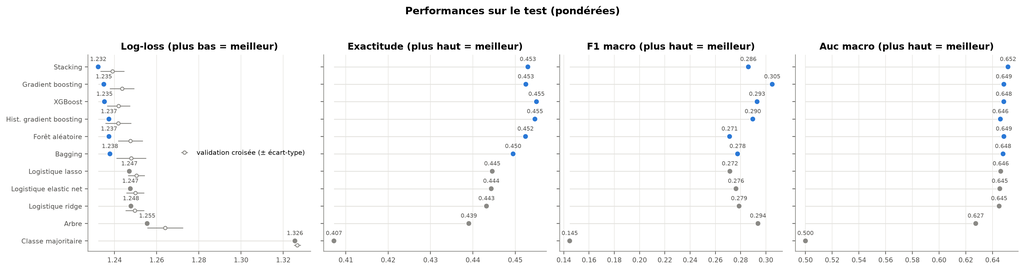

```python
REF_CLF = ("Classe majoritaire", *LOGITS, "Arbre")
order = res_clf.sort_values("log-loss test", ascending=False)
best_clf = next(n for n in order.index[::-1] if n not in REF_CLF)

colors = [GREY if n in REF_CLF else BLUE for n in order.index]
pos = np.arange(len(order))
fig, axes = plt.subplots(1, 4, figsize=(17, 4.5), sharey=True)
for ax, metric in zip(axes, ("log-loss test", "exactitude test", "F1 macro test",
                             "AUC macro test")):
    ax.hlines(pos, order[metric].min(), order[metric], color="#e4e3df", linewidth=1)
    ax.scatter(order[metric], pos, color=colors, s=45, zorder=3, edgecolor="white")
    for p_, v in zip(pos, order[metric]):
        ax.annotate(f"{v:.3f}", (v, p_), xytext=(0, 7), textcoords="offset points",
                    ha="center", fontsize=7, color=TEXT)
    sens = "plus bas = meilleur" if "loss" in metric else "plus haut = meilleur"
    ax.set_title(f"{metric.replace(' test', '').capitalize()} ({sens})")
    ax.set_yticks(pos, order.index)
    ax.set_ylim(-0.6, len(order) - 0.3)
    ax.grid(axis="y", visible=False)
axes[0].errorbar(order["log-loss CV"], pos - 0.25, xerr=order["± CV"], fmt="o", color=GREY,
                 markerfacecolor="white", markersize=4, elinewidth=1,
                 label="validation croisée (± écart-type)")
axes[0].legend(loc="center right")
fig.suptitle("Performances sur le test (pondérées)", fontweight="bold")
plt.tight_layout(rect=(0, 0, 1, 0.95))
plt.show()
```

Tous les modèles battent la classe majoritaire, mais les écarts entre eux sont faibles. Les méthodes d’agrégation (en bleu) font un peu mieux que les modèles de référence (en gris) : elles réduisent la log-loss de 6,6 à 7,0 %, contre 5,9 % pour les régressions logistiques. Entre les méthodes d’agrégation, les écarts de log-loss sont du même ordre que l’écart-type de la validation croisée (environ 0,006) : on ne peut pas vraiment les départager. L’exactitude ne dépasse pas 45,5 %, soit moins de 5 points de plus que la classe majoritaire.

## Analyse du meilleur modèle

### Matrice de confusion

Nous analysons maintenant le meilleur modèle d’agrégation. Dans la matrice de confusion, chaque ligne correspond à la classe observée et somme à 100 %.

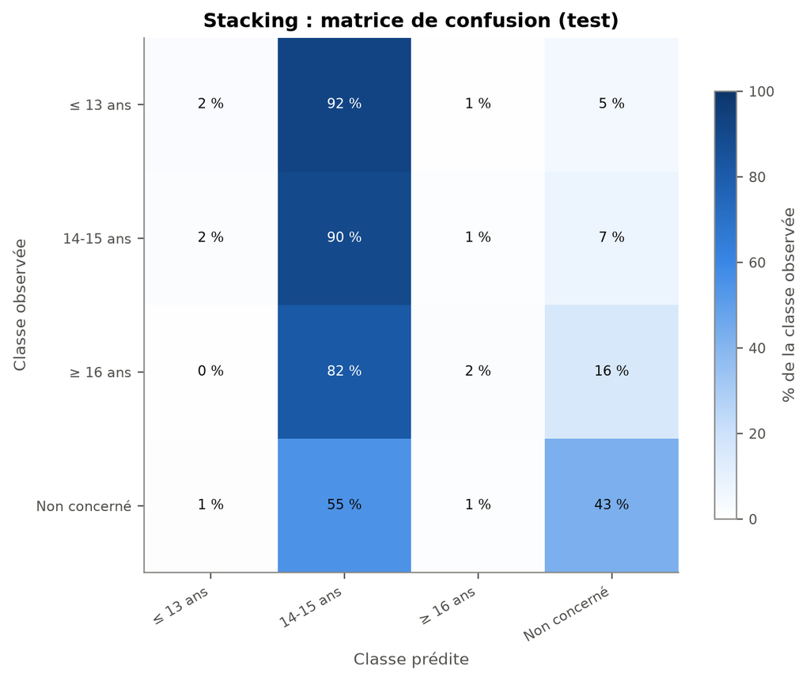

|  | % observé | % prédit | F1 |
| --- | --- | --- | --- |
| ≤ 13 ans | 18.957 | 1.436 | 0.045 |
| 14-15 ans | 40.720 | 81.893 | 0.596 |
| ≥ 16 ans | 21.816 | 1.349 | 0.038 |
| Non concerné | 18.507 | 15.322 | 0.466 |

```python
pred = FIT_CLF[best_clf].predict(Xc_test)
cm = confusion_matrix(yc_test, pred, labels=CLASSES, sample_weight=wc_test)
cm_pct = cm / cm.sum(1, keepdims=True) * 100

fig, ax = plt.subplots(figsize=(7, 5.5))
im = ax.imshow(cm_pct, cmap=LinearSegmentedColormap.from_list("ramp", BLUE_RAMP),
               vmin=0, vmax=100)
for i in range(len(CLASSES)):
    for j in range(len(CLASSES)):
        ax.text(j, i, f"{cm_pct[i, j]:.0f} %", ha="center", va="center", fontsize=8,
                color="white" if cm_pct[i, j] > 55 else "#0b0b0b")
ax.set_xticks(range(len(CLASSES)), CLASSES, rotation=30, ha="right")
ax.set_yticks(range(len(CLASSES)), CLASSES)
ax.set_xlabel("Classe prédite")
ax.set_ylabel("Classe observée")
ax.set_title(f"{best_clf} : matrice de confusion (test)")
ax.grid(False)
fig.colorbar(im, ax=ax, label="% de la classe observée", shrink=0.8)
plt.tight_layout()
plt.show()

pred_share = wc_test.groupby(pd.Series(pred, index=yc_test.index)).sum() / wc_test.sum() * 100
pd.DataFrame(
    {
        "% observé": wc_test.groupby(yc_test).sum() / wc_test.sum() * 100,
        "% prédit": pred_share,
        "F1": pd.Series(
            f1_score(yc_test, pred, labels=CLASSES, average=None, sample_weight=wc_test),
            index=CLASSES,
        ),
    }
).reindex(CLASSES).fillna(0).round(3)
```

Le modèle classe environ 82 % des jeunes dans la classe « 14-15 ans ». Les classes « ≤ 13 ans » et « ≥ 16 ans » ne sont presque jamais prédites (F1 d’environ 0,04). Seule la classe « Non concerné » est en partie reconnue : 43 % des jeunes n’ayant jamais bu sont bien classés.

### Probabilités et AUC par classe

Le modèle ne prédit presque jamais les classes précoce et tardive, mais cela ne veut pas dire qu’il n’a aucune information sur elles. Le tableau suivant donne la probabilité moyenne attribuée à chaque classe selon la classe observée, à comparer avec la fréquence de base.

```python
proba = pd.DataFrame(FIT_CLF[best_clf].predict_proba(Xc_test),
                     columns=FIT_CLF[best_clf].classes_, index=yc_test.index)[CLASSES]
mean_proba = proba.mul(wc_test, axis=0).groupby(yc_test).sum().div(
    wc_test.groupby(yc_test).sum(), axis=0
).reindex(CLASSES) * 100
mean_proba.loc["Fréquence de base"] = (
    wc_train.groupby(yc_train).sum().reindex(CLASSES) / wc_train.sum() * 100
)
mean_proba.round(1)
```

| Q19A_CLASSE | ≤ 13 ans | 14-15 ans | ≥ 16 ans | Non concerné |
| --- | --- | --- | --- | --- |
| ≤ 13 ans | 23.5 | 43.5 | 20.3 | 12.6 |
| 14-15 ans | 20.5 | 42.9 | 22.2 | 14.4 |
| ≥ 16 ans | 18.0 | 40.0 | 23.4 | 18.7 |
| Non concerné | 14.6 | 33.1 | 21.8 | 30.6 |
| Fréquence de base | 19.2 | 40.5 | 22.1 | 18.2 |

L’AUC par classe mesure la capacité du modèle à donner une probabilité plus élevée pour une classe aux jeunes qui en font vraiment partie (0,5 correspond au hasard).

```python
auc_class = pd.DataFrame(
    {
        name: [
            roc_auc_score(yc_test == c, FIT_CLF[name].predict_proba(Xc_test)[:, i],
                          sample_weight=wc_test)
            for i, c in enumerate(FIT_CLF[name].classes_)
        ]
        for name in ("Logistique ridge", "XGBoost", best_clf)
    },
    index=FIT_CLF[best_clf].classes_,
).reindex(CLASSES)
auc_class.loc["Macro"] = auc_class.mean()
auc_class.round(3)
```

|  | Logistique ridge | XGBoost | Stacking |
| --- | --- | --- | --- |
| ≤ 13 ans | 0.667 | 0.664 | 0.670 |
| 14-15 ans | 0.603 | 0.605 | 0.610 |
| ≥ 16 ans | 0.583 | 0.587 | 0.589 |
| Non concerné | 0.728 | 0.738 | 0.738 |
| Macro | 0.645 | 0.648 | 0.652 |

Les jeunes n’ayant jamais bu sont les mieux repérés (AUC de 0,74) : le modèle leur attribue en moyenne 31 % de probabilité d’être « Non concerné », contre 18 % pour la fréquence de base. Viennent ensuite les précoces (AUC de 0,67). Les classes « 14-15 ans » et « ≥ 16 ans » sont à peine mieux séparées qu’au hasard (0,61 et 0,59). Le signal sur les précoces existe donc, mais il est trop faible pour que le modèle les prédise.

### Importance des variables

Pour savoir quelles variables comptent, nous mesurons la hausse de la log-loss sur l’échantillon test quand on mélange au hasard les valeurs d’une variable (importance par permutation). Nous comparons la régression logistique ridge et le meilleur modèle d’agrégation.

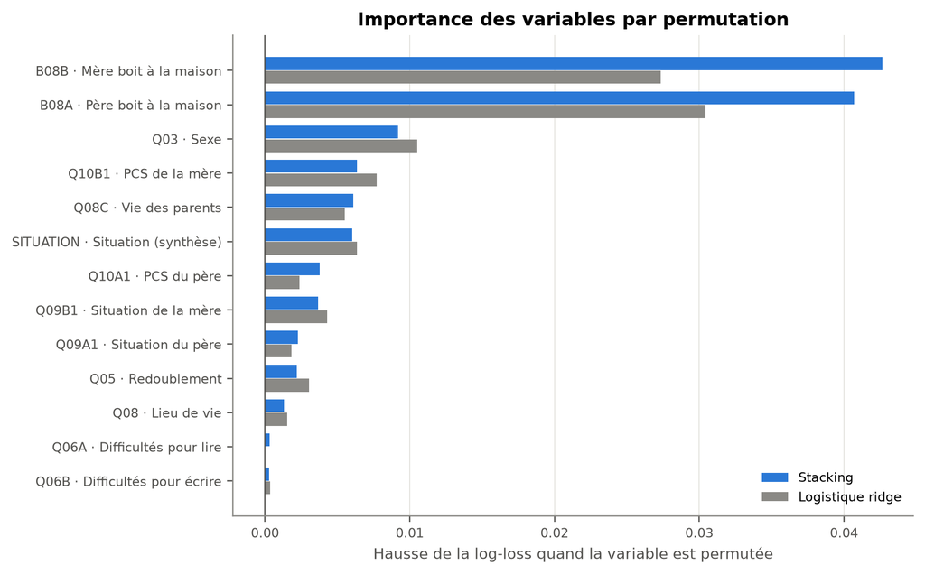

```python
def importance(pipe, X, y, w, scoring):
    r = permutation_importance(pipe, X, y, sample_weight=w.to_numpy(), scoring=scoring,
                               n_repeats=20, random_state=SEED, n_jobs=N_JOBS)
    return pd.Series(r.importances_mean, index=FEATURES)


def plot_importance(imp: pd.DataFrame, ref: str, best: str, xlabel: str):
    labels = [f"{v} · {VARIABLES[v][0]}" if v in VARIABLES else f"{v} · Situation (synthèse)"
              for v in imp.index]
    fig, ax = plt.subplots(figsize=(8, 5))
    pos = np.arange(len(imp))
    ax.barh(pos + 0.2, imp[best], height=0.38, color=BLUE, label=best)
    ax.barh(pos - 0.2, imp[ref], height=0.38, color=GREY, label=ref)
    ax.set_yticks(pos, labels)
    ax.axvline(0, color=TEXT, linewidth=0.8)
    ax.set_xlabel(xlabel)
    ax.set_title("Importance des variables par permutation")
    ax.legend(loc="lower right")
    ax.grid(axis="y", visible=False)
    plt.tight_layout()
    plt.show()


imp_clf = pd.DataFrame(
    {n: importance(FIT_CLF[n], Xc_test, yc_test, wc_test, "neg_log_loss")
     for n in ("Logistique ridge", best_clf)}
).sort_values(best_clf)
plot_importance(imp_clf, "Logistique ridge", best_clf,
                "Hausse de la log-loss quand la variable est permutée")
```

La consommation d’alcool des parents domine très nettement : permuter celle de la mère ou celle du père fait perdre bien plus que toute autre variable. Viennent ensuite le sexe, puis la PCS de la mère, la vie des parents et `SITUATION`. Les difficultés de lecture et d’écriture n’apportent rien.

# Conclusion

- **Le pouvoir prédictif est faible.** Le meilleur modèle, le stacking, réduit la log-loss de 7 % par rapport à la classe majoritaire, et son exactitude (45,3 %) ne dépasse la référence (40,7 %) que de moins de 5 points. Les variables disponibles, qui décrivent la situation personnelle et le contexte familial, n’expliquent qu’une petite partie de l’âge au premier alcool.
- **Les méthodes d’agrégation font un peu mieux que les modèles simples.** Elles réduisent la log-loss de 6,6 à 7,0 %, contre 5,9 % pour les régressions logistiques et 5,3 % pour l’arbre seul. Entre elles, les écarts restent de l’ordre de l’incertitude de la validation croisée : bagging, forêt aléatoire, boosting, XGBoost et stacking sont pratiquement équivalents.
- **Le modèle prédit presque toujours la classe « 14-15 ans ».** Environ 82 % des jeunes y sont classés, et les classes « ≤ 13 ans » et « ≥ 16 ans » ne sont presque jamais prédites. Seuls les jeunes n’ayant jamais bu sont en partie reconnus (43 % bien classés, AUC de 0,74).
- **Le signal existe mais reste faible.** Les probabilités prédites s’écartent des fréquences de base dans le bon sens, en particulier pour les jeunes n’ayant jamais bu et pour les précoces (AUC de 0,67), mais pas assez pour changer la classe prédite.
- **La consommation d’alcool des parents est de loin la variable la plus importante**, suivie du sexe. Cela rejoint l’analyse des classes : la consommation des parents distingue surtout les jeunes n’ayant jamais bu, et dans une moindre mesure les précoces.

Pour mieux repérer les précoces et les tardifs, on pourrait modifier la règle de décision, par exemple en fixant des seuils sur les probabilités ou en pondérant les classes (`class_weight`), au prix d’une exactitude plus faible.